# Collges - Pan-India

### Document History

Original Publish Date: 19 August, 2021

Updated on: 09:08 AM – 26 August, 2021

# India

## Observations

Observations

[output not shown]

## Summary

No

Variable

Stats / Values

Freqs (% of Valid)

Graph

Missing

1

country  
[character]

1. India

101377 (100.0%)

0  
(0.0%)

2

state  
[character]

1. uttar pradesh  
2. maharashtra  
3. karnataka  
4. rajasthan  
5. tamil nadu  
6. madhya pradesh  
7. gujarat  
8. west bengal  
9. haryana  
10. kerala  
[ 24 others ]

24084 (23.8%)  
13028 (12.9%)  
11559 (11.4%)  
7720 ( 7.6%)  
7265 ( 7.2%)  
6047 ( 6.0%)  
4189 ( 4.1%)  
4001 ( 3.9%)  
3810 ( 3.8%)  
3664 ( 3.6%)  
16010 (15.8%)

0  
(0.0%)

3

district  
[character]

1. Bengaluru Urban  
2. Pune  
3. Prayagraj  
4. Jaipur  
5. Lucknow  
6. Meerut  
7. Nagpur  
8. Sikar  
9. Ghaziabad  
10. Kalaburagi  
[ 663 others ]

2957 ( 2.9%)  
1503 ( 1.5%)  
1268 ( 1.3%)  
1264 ( 1.2%)  
1129 ( 1.1%)  
1069 ( 1.1%)  
1050 ( 1.0%)  
831 ( 0.8%)  
734 ( 0.7%)  
727 ( 0.7%)  
88845 (87.6%)

0  
(0.0%)

4

univ_type  
[character]

1. (Empty string)  
2. Central University  
3. Deemed University-Governm  
4. Deemed University-Private  
5. Institute of National Imp  
6. State Private University  
7. State Public University

20192 (19.9%)  
1094 ( 1.1%)  
12 ( 0.0%)  
176 ( 0.2%)  
48 ( 0.0%)  
331 ( 0.3%)  
79524 (78.4%)

0  
(0.0%)

5

univ_name  
[character]

1. (Empty string)  
2. Chatrapati Sahuji Maharaj  
3. Dr. B. R. Ambedkar Univer  
4. Choudhary Charan Singh Un  
5. Dr.A.P.J. ABDUL KALAM TEC  
6. Dr. Ram Manohar Lohia Aw  
7. ALLAHABAD STATE UNIVERSIT  
8. Rajiv Gandhi University o  
9. Makhanlal Chaturvedi Nati  
10. Savitribai Phule Pune Uni  
[ 290 others ]

20192 (19.9%)  
2826 ( 2.8%)  
2407 ( 2.4%)  
2310 ( 2.3%)  
2113 ( 2.1%)  
2014 ( 2.0%)  
1830 ( 1.8%)  
1698 ( 1.7%)  
1662 ( 1.6%)  
1517 ( 1.5%)  
62808 (62.0%)

0  
(0.0%)

6

inst_name  
[character]

1. SOUTH KASHMIR TEACHERS TR  
2. Alamganj Rangamati Colleg  
3. Dharamsala College (Id: C  
4. Dhubri P.G.T.T. College (  
5. DIET DHUBRI (Id: S-5698)  
6. Dolgoma Anchalik College  
7. Halakura College (Id: C-1  
8. JAN BAZ WALI COLLEGE OF E  
9. JEHLUM EDUCATION TRUST, B  
10. Progati College (Id: C-17  
[ 34999 others ]

9 ( 0.0%)  
7 ( 0.0%)  
7 ( 0.0%)  
7 ( 0.0%)  
7 ( 0.0%)  
7 ( 0.0%)  
7 ( 0.0%)  
7 ( 0.0%)  
7 ( 0.0%)  
7 ( 0.0%)  
101305 (99.9%)

[figure not shown]

0  
(0.0%)

7

inst_type  
[character]

1. Affiliated College  
2. Constituent / University  
3. PG Center / Off-Campus Ce  
4. Recognized Center  
5. stand_alone

78190 (77.1%)  
795 ( 0.8%)  
67 ( 0.1%)  
2133 ( 2.1%)  
20192 (19.9%)

0  
(0.0%)

8

address  
[character]

1. Behind Circuit House, Jai  
2. 0, 0, 0  
3. VILL-PARVATPUR CHANDRIKA  
4. GAURA MOHANLALGANJ, RAEBA  
5. At: Gauridad, Rajkot-Morb  
6. VIDYA KNOWLEDGE PARK, BAG  
7. MANDAWA ROAD, GANPATI NAG  
8. 09 Mile Stone, Roorkee -  
9. NH 58 Jatoli Meerut, Meer  
10. Plot No- 643,644, Behind  
[ 34260 others ]

30 ( 0.0%)  
21 ( 0.0%)  
18 ( 0.0%)  
17 ( 0.0%)  
16 ( 0.0%)  
16 ( 0.0%)  
15 ( 0.0%)  
14 ( 0.0%)  
14 ( 0.0%)  
14 ( 0.0%)  
101202 (99.8%)

[figure not shown]

0  
(0.0%)

9

website  
[character]

1. (Empty string)  
2. www.gfgc.kar.nic.in  
3. 0  
4. -  
5. www.sinhgad.edu  
6. www.hte.rajasthan.gov.in  
7. www.highereduhry.com  
8. dce.rajasthan.gov.in  
9. www.dce.rajasthan.gov.in  
10. NIL  
[ 24397 others ]

20512 (20.2%)  
106 ( 0.1%)  
81 ( 0.1%)  
75 ( 0.1%)  
68 ( 0.1%)  
53 ( 0.1%)  
52 ( 0.1%)  
41 ( 0.0%)  
40 ( 0.0%)  
39 ( 0.0%)  
80310 (79.2%)

0  
(0.0%)

10

management  
[character]

1. Central Government  
2. Local Body  
3. Private Aided  
4. Private Un-Aided  
5. State Government

391 ( 0.4%)  
4953 ( 4.9%)  
7450 ( 7.3%)  
78368 (77.3%)  
10215 (10.1%)

0  
(0.0%)

11

year_estd  
[integer]

Mean (sd) : 2007.8 (6.9)  
min < med < max:  
1989 < 2008 < 2020  
IQR (CV) : 9 (0)

32 distinct values

0  
(0.0%)

12

specialisation  
[character]

1. No  
2. Nursing  
3. Education/Teacher Educati  
4. Technical/Polytechnic  
5. Teacher Training  
6. Engineering & Technology  
7. Arts  
8. Pharmacy  
9. Management  
10. Law  
[ 331 others ]

52894 (52.2%)  
8757 ( 8.6%)  
7088 ( 7.0%)  
7082 ( 7.0%)  
6129 ( 6.0%)  
3070 ( 3.0%)  
2013 ( 2.0%)  
1664 ( 1.6%)  
1650 ( 1.6%)  
1265 ( 1.2%)  
9765 ( 9.6%)

0  
(0.0%)

13

location  
[character]

1. Rural  
2. Urban

64775 (63.9%)  
36602 (36.1%)

0  
(0.0%)

14

year_upload  
[character]

1. 2010  
2. 2011  
3. 2012  
4. 2013  
5. 2014  
6. 2015  
7. 2016  
8. 2017  
9. 2018  
10. 2019

294 ( 0.3%)  
73 ( 0.1%)  
228 ( 0.2%)  
103 ( 0.1%)  
748 ( 0.7%)  
1688 ( 1.7%)  
2070 ( 2.0%)  
1676 ( 1.7%)  
4295 ( 4.2%)  
90202 (89.0%)

0  
(0.0%)

15

lat  
[numeric]

Mean (sd) : 22.1 (6.2)  
min < med < max:  
8.1 < 23.3 < 34.5  
IQR (CV) : 9.1 (0.3)

25798 distinct values

0  
(0.0%)

16

long  
[numeric]

Mean (sd) : 78.5 (4.1)  
min < med < max:  
69 < 77.6 < 96.2  
IQR (CV) : 4.4 (0.1)

25690 distinct values

0  
(0.0%)

17

delim  
[character]

1. post_delim  
2. pre_delim

50223 (49.5%)  
51154 (50.5%)

0  
(0.0%)

18

st_code  
[character]

1. 9  
2. S24  
3. S13  
4. S10  
5. 27  
6. S22  
7. S20  
8. 29  
9. 8  
10. S12  
[ 54 others ]

14827 (14.6%)  
9212 ( 9.1%)  
7818 ( 7.7%)  
7694 ( 7.6%)  
5190 ( 5.1%)  
4167 ( 4.1%)  
4107 ( 4.1%)  
3884 ( 3.8%)  
3617 ( 3.6%)  
3156 ( 3.1%)  
37705 (37.2%)

0  
(0.0%)

19

st_name  
[character]

1. UTTAR PRADESH  
2. MAHARASHTRA  
3. KARNATAKA  
4. RAJASTHAN  
5. TAMIL NADU  
6. MADHYA PRADESH  
7. GUJARAT  
8. WEST BENGAL  
9. HARYANA  
10. KERALA  
[ 27 others ]

24039 (23.7%)  
13008 (12.8%)  
11578 (11.4%)  
7724 ( 7.6%)  
7265 ( 7.2%)  
6027 ( 5.9%)  
4221 ( 4.2%)  
3972 ( 3.9%)  
3781 ( 3.7%)  
3644 ( 3.6%)  
16118 (15.9%)

0  
(0.0%)

20

pc_no  
[integer]

Mean (sd) : 21 (18.7)  
min < med < max:  
1 < 15 < 80  
IQR (CV) : 22 (0.9)

80 distinct values

0  
(0.0%)

21

pc_name  
[character]

1. Kanakapura  
2. Bangalore North  
3. Nagpur  
4. Bangalore South  
5. MALKAJGIRI  
6. Jaipur  
7. Mahendragarh  
8. MOHANLALGANJ (SC)  
9. Hoshangabad  
10. Sikar  
[ 978 others ]

966 ( 1.0%)  
681 ( 0.7%)  
655 ( 0.6%)  
642 ( 0.6%)  
609 ( 0.6%)  
521 ( 0.5%)  
513 ( 0.5%)  
504 ( 0.5%)  
498 ( 0.5%)  
491 ( 0.5%)  
95297 (94.0%)

0  
(0.0%)

22

year_el  
[factor]

1. 1989  
2. 1991  
3. 1996  
4. 1998  
5. 1999  
6. 2004  
7. 2009  
8. 2014  
9. 2019

1618 ( 1.6%)  
5858 ( 5.8%)  
2798 ( 2.8%)  
1316 ( 1.3%)  
10429 (10.3%)  
29135 (28.7%)  
27492 (27.1%)  
20475 (20.2%)  
2256 ( 2.2%)

0  
(0.0%)

23

position  
[integer]

Mean (sd) : 2.1 (1)  
min < med < max:  
1 < 2 < 9  
IQR (CV) : 2 (0.5)

1 : 35009 (34.5%)  
2 : 35005 (34.5%)  
3 : 22538 (22.2%)  
4 : 7550 ( 7.4%)  
5 : 1217 ( 1.2%)  
6 : 45 ( 0.0%)  
7 : 11 ( 0.0%)  
8 : 1 ( 0.0%)  
9 : 1 ( 0.0%)

0  
(0.0%)

24

caste_rec  
[character]

1. (Empty string)  
2. UC  
3. OBC  
4. SC  
5. IC  
6. MUSLIM  
7. ST  
8. GEN  
9. IC SIKH  
10. UC MUSLIM  
[ 15 others ]

56540 (55.8%)  
13220 (13.0%)  
9654 ( 9.5%)  
7418 ( 7.3%)  
6213 ( 6.1%)  
2661 ( 2.6%)  
2604 ( 2.6%)  
825 ( 0.8%)  
733 ( 0.7%)  
503 ( 0.5%)  
1006 ( 1.0%)

0  
(0.0%)

25

dyn  
[character]

1. (Empty string)  
2. 0  
3. 1  
4. Recheck

23055 (22.7%)  
56101 (55.3%)  
22120 (21.8%)  
101 ( 0.1%)

0  
(0.0%)

26

source  
[character]

1. TALHA  
2. (Empty string)  
3. Patrick French  
4. Not Known  
5. Rakesh  
6. Sriniwas  
7. Somnath  
8. Lakshmikant  
9. Rama  
10. Walru  
[ 35 others ]

28200 (27.8%)  
23173 (22.9%)  
11932 (11.8%)  
5783 ( 5.7%)  
4534 ( 4.5%)  
3306 ( 3.3%)  
2952 ( 2.9%)  
2873 ( 2.8%)  
2845 ( 2.8%)  
1939 ( 1.9%)  
13840 (13.7%)

0  
(0.0%)

27

background  
[character]

1. No significant political  
2. (Empty string)  
3. No significant family bac  
4. Family - Son  
5. Business  
6. Family  
7. Student politics  
8. RSS  
9. Family - Multiple connect  
10. Family-Son  
[ 1050 others ]

30669 (30.3%)  
23031 (22.7%)  
6768 ( 6.7%)  
2128 ( 2.1%)  
1980 ( 2.0%)  
1534 ( 1.5%)  
1438 ( 1.4%)  
1218 ( 1.2%)  
1204 ( 1.2%)  
729 ( 0.7%)  
30678 (30.3%)

0  
(0.0%)

28

notes  
[character]

1. (Empty string)  
2. Hindutva Movment  
3. Buisness  
4. A law graduate, Kumar mad  
5. Born to a farmer in 1933,  
6. 3rd term MP, began as a c  
7. Started out as a function  
8. He is a social worker who  
9. Trible Network  
10. He participated in theÂ G  
[ 1465 others ]

62254 (61.4%)  
613 ( 0.6%)  
389 ( 0.4%)  
277 ( 0.3%)  
244 ( 0.2%)  
221 ( 0.2%)  
208 ( 0.2%)  
199 ( 0.2%)  
189 ( 0.2%)  
187 ( 0.2%)  
36596 (36.1%)

0  
(0.0%)

29

election_type  
[character]

1. GE

101377 (100.0%)

0  
(0.0%)

30

assembly_no  
[integer]

Mean (sd) : 14.2 (1.7)  
min < med < max:  
9 < 14 < 17  
IQR (CV) : 1 (0.1)

9 : 1618 ( 1.6%)  
10 : 5858 ( 5.8%)  
11 : 2798 ( 2.8%)  
12 : 1316 ( 1.3%)  
13 : 10429 (10.3%)  
14 : 29135 (28.7%)  
15 : 27492 (27.1%)  
16 : 20475 (20.2%)  
17 : 2256 ( 2.2%)

0  
(0.0%)

31

month  
[integer]

Mean (sd) : 4.7 (1.7)  
min < med < max:  
3 < 4 < 11  
IQR (CV) : 0 (0.4)

3 : 1316 ( 1.3%)  
4 : 82156 (81.0%)  
5 : 5858 ( 5.8%)  
9 : 10429 (10.3%)  
11 : 1618 ( 1.6%)

0  
(0.0%)

32

poll_no  
[integer]

1 distinct value

0 : 101377 (100.0%)

0  
(0.0%)

33

delimid  
[integer]

Min : 3  
Mean : 3.5  
Max : 4

3 : 51154 (50.5%)  
4 : 50223 (49.5%)

0  
(0.0%)

34

candidate  
[character]

1. GIRDHARI LAL BHARGAVA  
2. ANANTH KUMAR  
3. RAMACHANDRA GOWDA  
4. PRATAP SINGH KHACHARIAWAS  
5. MALLIKARJUN KHARGE  
6. MALOOK NAGAR  
7. DEVEGOWDA H D  
8. TEJASHWINI SEE RAMESH  
9. SANTOSH AHLAWAT  
10. PRASANNA KUMAR PATASANI  
[ 8124 others ]

204 ( 0.2%)  
194 ( 0.2%)  
187 ( 0.2%)  
182 ( 0.2%)  
171 ( 0.2%)  
170 ( 0.2%)  
155 ( 0.2%)  
155 ( 0.2%)  
153 ( 0.2%)  
150 ( 0.1%)  
99656 (98.3%)

[figure not shown]

0  
(0.0%)

35

sex  
[character]

1. F  
2. M

8976 ( 8.9%)  
92401 (91.1%)

0  
(0.0%)

36

party  
[character]

1. INC  
2. BJP  
3. BSP  
4. SP  
5. CPM  
6. JD(S)  
7. NCP  
8. IND  
9. SHS  
10. ADMK  
[ 195 others ]

27562 (27.2%)  
26570 (26.2%)  
9650 ( 9.5%)  
5958 ( 5.9%)  
2628 ( 2.6%)  
2511 ( 2.5%)  
2090 ( 2.1%)  
2072 ( 2.0%)  
2045 ( 2.0%)  
1743 ( 1.7%)  
18548 (18.3%)

0  
(0.0%)

37

votes  
[integer]

Mean (sd) : 261143.4 (150061.3)  
min < med < max:  
3422 < 250272 < 1068569  
IQR (CV) : 213144 (0.6)

9516 distinct values

0  
(0.0%)

38

candidate_type  
[character]

1. (Empty string)  
2. GEN  
3. SC  
4. ST

14665 (14.5%)  
68879 (67.9%)  
13430 (13.2%)  
4403 ( 4.3%)

0  
(0.0%)

39

valid_votes  
[integer]

Mean (sd) : 804689.9 (224584.5)  
min < med < max:  
36538 < 769018 < 1629108  
IQR (CV) : 279842 (0.3)

3266 distinct values

0  
(0.0%)

40

electors  
[integer]

Mean (sd) : 1403927 (337038.1)  
min < med < max:  
56719 < 1376267 < 3368399  
IQR (CV) : 393182 (0.2)

3267 distinct values

0  
(0.0%)

41

constituency_name  
[character]

1. BANGALORE NORTH  
2. KANAKAPURA  
3. SIKAR  
4. BANGALORE SOUTH  
5. JAIPUR  
6. NAGPUR  
7. MEERUT  
8. GWALIOR  
9. GULBARGA  
10. AGRA  
[ 658 others ]

1015 ( 1.0%)  
963 ( 0.9%)  
855 ( 0.8%)  
836 ( 0.8%)  
832 ( 0.8%)  
830 ( 0.8%)  
729 ( 0.7%)  
718 ( 0.7%)  
699 ( 0.7%)  
686 ( 0.7%)  
93214 (91.9%)

0  
(0.0%)

42

constituency_type  
[character]

1. GEN  
2. SC  
3. ST

82680 (81.6%)  
14335 (14.1%)  
4362 ( 4.3%)

0  
(0.0%)

43

sub_region  
[character]

1. (Empty string)  
2. AVADH  
3. BUNDELKHAND  
4. DOAB  
5. EAST  
6. NORTH-EAST  
7. RUHELKHAND  
8. TELENGANA  
9. WEST

83908 (82.8%)  
2850 ( 2.8%)  
833 ( 0.8%)  
3267 ( 3.2%)  
2987 ( 2.9%)  
1346 ( 1.3%)  
1661 ( 1.6%)  
2620 ( 2.6%)  
1905 ( 1.9%)

0  
(0.0%)

44

n_cand  
[integer]

Mean (sd) : 14.4 (10.6)  
min < med < max:  
2 < 13 < 456  
IQR (CV) : 8 (0.7)

67 distinct values

0  
(0.0%)

45

turnout_percentage  
[numeric]

Mean (sd) : 57.8 (11.5)  
min < med < max:  
8.9 < 57 < 91.7  
IQR (CV) : 17 (0.2)

2302 distinct values

0  
(0.0%)

46

vote_share_percentage  
[numeric]

Mean (sd) : 32.3 (15.5)  
min < med < max:  
5 < 34.4 < 90.1  
IQR (CV) : 24.8 (0.5)

4564 distinct values

0  
(0.0%)

47

deposit_lost  
[character]

1. no  
2. yes

79687 (78.6%)  
21690 (21.4%)

0  
(0.0%)

48

margin  
[integer]

Mean (sd) : 124984.8 (109567.1)  
min < med < max:  
0 < 88896 < 665350  
IQR (CV) : 144013 (0.9)

9381 distinct values

0  
(0.0%)

49

margin_percentage  
[numeric]

Mean (sd) : 15.4 (12.4)  
min < med < max:  
0 < 11.7 < 86.9  
IQR (CV) : 17.8 (0.8)

3624 distinct values

0  
(0.0%)

50

enop  
[numeric]

Mean (sd) : 3 (0.8)  
min < med < max:  
1.2 < 2.9 < 10  
IQR (CV) : 1.1 (0.3)

54 distinct values

0  
(0.0%)

51

pid  
[character]

1. AERJ17798  
2. GEKA15636  
3. GERJ38827  
4. GEKA14523  
5. AEKA107680  
6. AERJ17833  
7. GEMH70725  
8. GEKA11558  
9. GEMH27078  
10. GEDL35837  
[ 6136 others ]

285 ( 0.3%)  
277 ( 0.3%)  
258 ( 0.3%)  
254 ( 0.3%)  
239 ( 0.2%)  
227 ( 0.2%)  
221 ( 0.2%)  
220 ( 0.2%)  
215 ( 0.2%)  
214 ( 0.2%)  
98967 (97.6%)

[figure not shown]

0  
(0.0%)

52

party_type_tcpd  
[logical]

All NA’s

101377  
(100.0%)

53

party_id  
[integer]

Mean (sd) : 6307.4 (5480)  
min < med < max:  
13 < 3482 < 24559  
IQR (CV) : 9204 (0.9)

195 distinct values

0  
(0.0%)

54

last_poll  
[logical]

1. FALSE  
2. TRUE

4865 ( 4.8%)  
96512 (95.2%)

0  
(0.0%)

55

contested  
[integer]

Mean (sd) : 2.4 (2.1)  
min < med < max:  
1 < 1 < 16  
IQR (CV) : 2 (0.9)

16 distinct values

0  
(0.0%)

56

last_party  
[character]

1. (Empty string)  
2. INC  
3. BJP  
4. SP  
5. BSP  
6. IND  
7. CPM  
8. JD  
9. SHS  
10. NCP  
[ 150 others ]

51157 (50.5%)  
14900 (14.7%)  
13995 (13.8%)  
3029 ( 3.0%)  
2213 ( 2.2%)  
1907 ( 1.9%)  
1491 ( 1.5%)  
1227 ( 1.2%)  
996 ( 1.0%)  
672 ( 0.7%)  
9790 ( 9.7%)

0  
(0.0%)

57

last_party_id  
[integer]

Mean (sd) : 5715.7 (4902)  
min < med < max:  
13 < 3482 < 18691  
IQR (CV) : 5970 (0.9)

143 distinct values

51157  
(50.5%)

58

last_constituency_name  
[character]

1. (Empty string)  
2. KANAKAPURA  
3. SIKAR  
4. GULBARGA  
5. BANGALORE NORTH  
6. BANGALORE SOUTH  
7. GWALIOR  
8. MEERUT  
9. NAGPUR  
10. MAHENDRAGARH  
[ 679 others ]

51157 (50.5%)  
825 ( 0.8%)  
668 ( 0.7%)  
532 ( 0.5%)  
471 ( 0.5%)  
428 ( 0.4%)  
371 ( 0.4%)  
345 ( 0.3%)  
343 ( 0.3%)  
339 ( 0.3%)  
45898 (45.3%)

0  
(0.0%)

59

same_constituency  
[logical]

1. FALSE  
2. TRUE

12623 (25.1%)  
37597 (74.9%)

51157  
(50.5%)

60

same_party  
[logical]

1. FALSE  
2. TRUE

11567 (23.0%)  
38653 (77.0%)

51157  
(50.5%)

61

no_terms  
[integer]

Mean (sd) : 1.2 (1.6)  
min < med < max:  
0 < 1 < 10  
IQR (CV) : 2 (1.4)

11 distinct values

0  
(0.0%)

62

turncoat  
[logical]

1. FALSE  
2. TRUE

91925 (90.7%)  
9452 ( 9.3%)

0  
(0.0%)

63

incumbent  
[logical]

1. FALSE  
2. TRUE

76099 (75.1%)  
25278 (24.9%)

0  
(0.0%)

64

recontest  
[logical]

1. FALSE  
2. TRUE

62314 (61.5%)  
39063 (38.5%)

0  
(0.0%)

65

age  
[logical]

All NA’s

101377  
(100.0%)

66

district_name  
[logical]

All NA’s

101377  
(100.0%)

## distribution of colleges at pc level

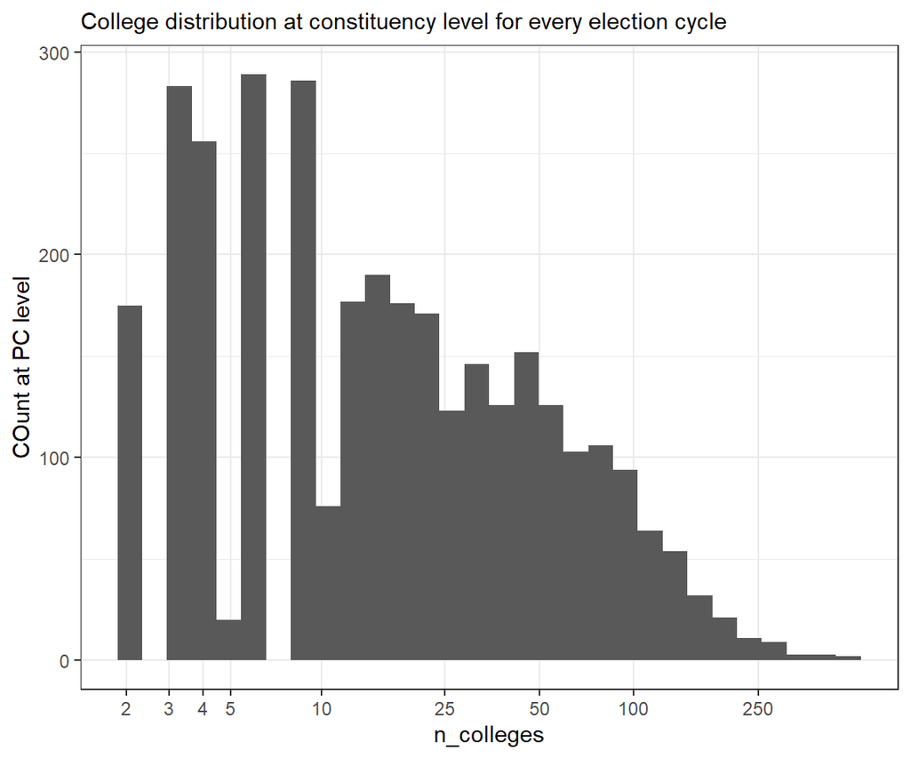

## colleges at pc level

[figure not shown]

## managment

| management | prop |
| --- | --- |
| Private Un-Aided | 0.77 |
| State Government | 0.10 |
| Private Aided | 0.07 |
| Local Body | 0.05 |
| Central Government | 0.00 |

## Colleges by state and year

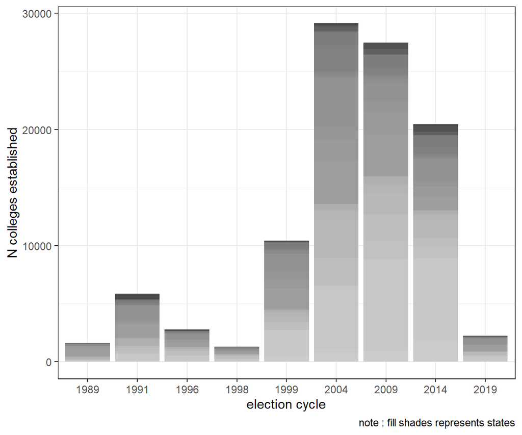

# rdd

### Summary

-Margin percentage (cut off) break up look like this:

| cut off | 2.5 | 5 | 10 |
| --- | --- | --- | --- |
| total | 78 | 165 | 297 |
| family winners | 40 | 86 | 167 |
| non-family winners | 38 | 79 | 130 |

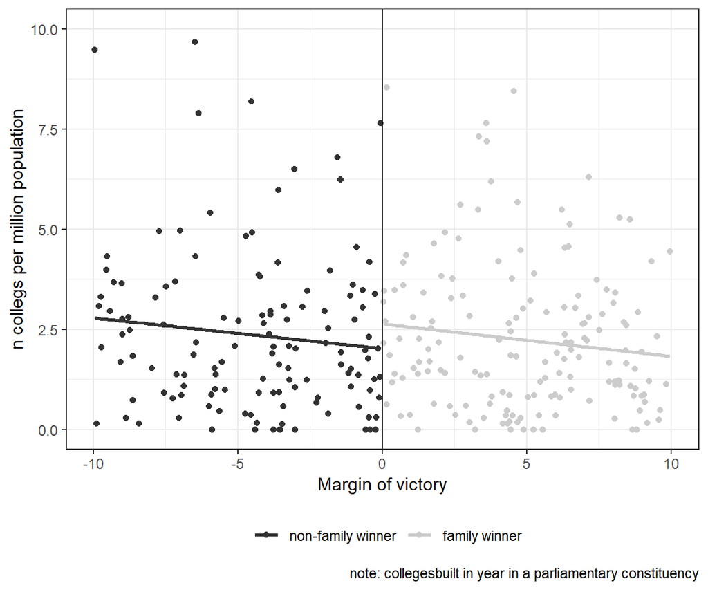

## rdd model

|  | *Dependent variable:* |  |  |
| --- | --- | --- | --- |
|  | n_college |  |  |
|  | 2,5 | 5 | 10 |
|  | (1) | (2) | (3) |
| family | 0.468 | 0.439 | 0.090 |
|  | (0.477) | (0.353) | (0.279) |
| Observations | 78 | 165 | 297 |
| R<sup>2</sup> | 0.012 | 0.009 | 0.0004 |
| Adjusted R<sup>2</sup> | -0.001 | 0.003 | -0.003 |
| Residual Std. Error | 2.107 (df = 76) | 2.265 (df = 163) | 2.389 (df = 295) |
| F Statistic | 0.961 (df = 1; 76) | 1.544 (df = 1; 163) | 0.105 (df = 1; 295) |
| *Note:* | p<0.1; p<0.05; p<0.01 |  |  |

## Further improvments

- Add more years
- do seperate ones for private/government college
- remove/keep standalone colleges